# Introducción a mutate, group_by y summarise

## 🔴 Mutate

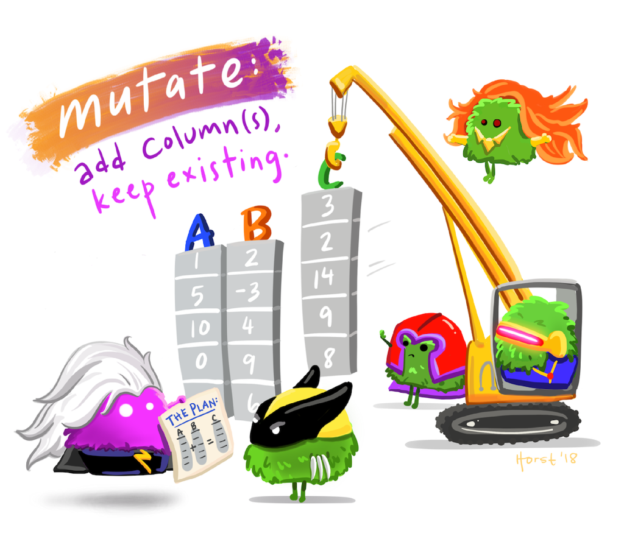

Función de `dplyr` que nos permite agregar o modificar las variables actuales en un conjunto de datos. Este mismo nos permite crear varias columnas a la vez, separando con una coma cada nueva variable, asimimo puedes usar otras funciones internas dentro de mutate para crear nuevas variables [**(Y. Wendy Huynh,2019).**](https://bookdown.org/yih_huynh/Guide-to-R-Book/mutate.html)

### Ejemplo práctico

Para este ejemplo usaremos una base de datos que contiene casos de personas fallecidas a causa del coranovirus a nivel de país, este dataset está alojada en el siguiente repositorio de GitHub [(click aquí)](https://github.com/CSSEGISandData/COVID-19) del Portal de datos abiertos.

[figure not shown]

#### Lectura de datos

```r
data <- read_csv("https://raw.githubusercontent.com/CSSEGISandData/COVID-19/master/csse_covid_19_data/csse_covid_19_time_series/time_series_covid19_deaths_global.csv")
head(data)
```

```
## # A tibble: 6 × 702
##   `Province/State` `Country/Region`     Lat   Long `1/22/20` `1/23/20` `1/24/20`
##   <chr>            <chr>              <dbl>  <dbl>     <dbl>     <dbl>     <dbl>
## 1 <NA>             Afghanistan         33.9  67.7          0         0         0
## 2 <NA>             Albania             41.2  20.2          0         0         0
## 3 <NA>             Algeria             28.0   1.66         0         0         0
## 4 <NA>             Andorra             42.5   1.52         0         0         0
## 5 <NA>             Angola             -11.2  17.9          0         0         0
## 6 <NA>             Antigua and Barbu…  17.1 -61.8          0         0         0
## # … with 695 more variables: 1/25/20 <dbl>, 1/26/20 <dbl>, 1/27/20 <dbl>,
## #   1/28/20 <dbl>, 1/29/20 <dbl>, 1/30/20 <dbl>, 1/31/20 <dbl>, 2/1/20 <dbl>,
## #   2/2/20 <dbl>, 2/3/20 <dbl>, 2/4/20 <dbl>, 2/5/20 <dbl>, 2/6/20 <dbl>,
## #   2/7/20 <dbl>, 2/8/20 <dbl>, 2/9/20 <dbl>, 2/10/20 <dbl>, 2/11/20 <dbl>,
## #   2/12/20 <dbl>, 2/13/20 <dbl>, 2/14/20 <dbl>, 2/15/20 <dbl>, 2/16/20 <dbl>,
## #   2/17/20 <dbl>, 2/18/20 <dbl>, 2/19/20 <dbl>, 2/20/20 <dbl>, 2/21/20 <dbl>,
## #   2/22/20 <dbl>, 2/23/20 <dbl>, 2/24/20 <dbl>, 2/25/20 <dbl>, …
```

#### Mutate para renombrar variables existentes

```r
newdata1 <- data %>%
  mutate(
    Pais = `Country/Region`,
    Latitud = Lat,
    Longitud = Lat) %>%
  select(Pais, Latitud, Longitud)
newdata1
```

```
## # A tibble: 280 × 3
##    Pais                Latitud Longitud
##    <chr>                 <dbl>    <dbl>
##  1 Afghanistan            33.9     33.9
##  2 Albania                41.2     41.2
##  3 Algeria                28.0     28.0
##  4 Andorra                42.5     42.5
##  5 Angola                -11.2    -11.2
##  6 Antigua and Barbuda    17.1     17.1
##  7 Argentina             -38.4    -38.4
##  8 Armenia                40.1     40.1
##  9 Australia             -35.5    -35.5
## 10 Australia             -33.9    -33.9
## # … with 270 more rows
```

### Mutate para crear nuevas columnas

```r
newdata2 <- newdata1 %>%
  mutate(Peligro = "COVID-19")
newdata2
```

```
## # A tibble: 280 × 4
##    Pais                Latitud Longitud Peligro
##    <chr>                 <dbl>    <dbl> <chr>
##  1 Afghanistan            33.9     33.9 COVID-19
##  2 Albania                41.2     41.2 COVID-19
##  3 Algeria                28.0     28.0 COVID-19
##  4 Andorra                42.5     42.5 COVID-19
##  5 Angola                -11.2    -11.2 COVID-19
##  6 Antigua and Barbuda    17.1     17.1 COVID-19
##  7 Argentina             -38.4    -38.4 COVID-19
##  8 Armenia                40.1     40.1 COVID-19
##  9 Australia             -35.5    -35.5 COVID-19
## 10 Australia             -33.9    -33.9 COVID-19
## # … with 270 more rows
```

### Observación: La función `Mutate` presenta algunas variantes entre ellas tenemos a:

- `mutate_all`
- `mutate_if`
- `mutate_each`
- `mutate_at`

## 🔴 Group by

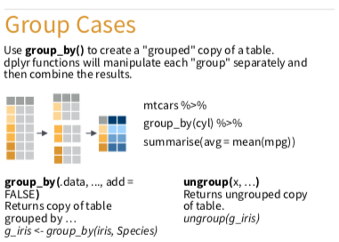

Función de `dplyr` que nos permite generar estadísticas resumidas a partir del agrupamiento de variables especificas, está función trabaja de forma cojunta con la función summarise.

### Observación: La función `Group by` presenta alguna variantes, estás son:

- `group_by_all`
- `group_by_at`
- `group_by_if`
- `group_by_prepare`

## 🔴 Summarise

Función de `dplyr` que trabaja de forma conjunta con group_by para obtener nuevos resumen en función al agrupamiento de filas.

- `summarise_all`
- `summarise_at`
- `summarise_if`
- `summarise_each`
- `summarise_coord`

## 🔴 Integración de Group_by + summarise

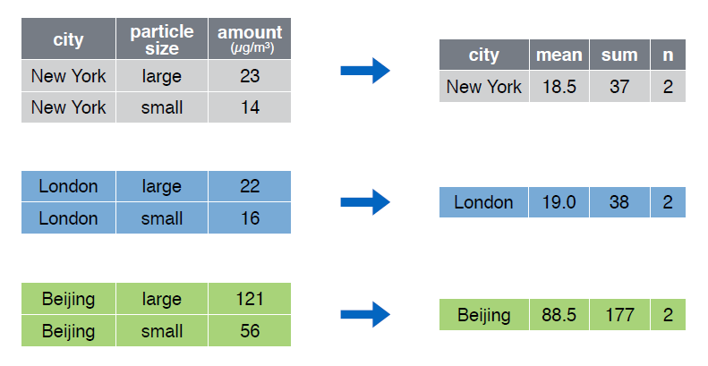

### Ejemplo práctico

Ordenamos la data de covid19 para todo los paises en un formato tidy usando la función `pivot_longer`

```r
tidydata <- data %>%
  pivot_longer(
    cols = !c("Province/State","Country/Region","Lat","Long"),
    names_to = "years",
    values_to = "fallecidos",
    values_drop_na = TRUE
    )
```

Ahora calculamos los valores **max**, **minimos**, **promedios** y **sd** hasta la fecha actual para cada el país de Perú usando la función `group_by` y `summarise`

```r
tidydata %>%
  filter(`Country/Region` =="Peru") %>%
  group_by(`Country/Region`) %>%
  summarise(
    total_max  = max(fallecidos,na.rm = TRUE),
    total_min  = min(fallecidos,na.rm = TRUE),
    total_mean = mean(fallecidos),
    tota_sd    = sd(fallecidos,na.rm = TRUE)
    ) %>%
  arrange(desc(total_max))
```

```
## # A tibble: 1 × 5
##   `Country/Region` total_max total_min total_mean tota_sd
##   <chr>                <dbl>     <dbl>      <dbl>   <dbl>
## 1 Peru                202225         0    108253.  72974.
```

## 🔴 Referencias

- Iosu Paradinas, Curso de R base, 2021, *https://bookdown.org/paradinas_iosu/CursoR/*
- Y.Wendy Huynh,R for Graduate Students,2019, *https://bookdown.org/yih_huynh/Guide-to-R-Book/*
- Roger D. Peng,R Programming for Data Science,2020,*https://bookdown.org/rdpeng/rprogdatascience/*
- The Ocean Health Index Team,Introduction to Open Data Science,2019,*https://ohi-science.org/data-science-training/*
- Rubén Sánchez Sancho,Programación con R,*https://rsanchezs.gitbooks.io/rprogramming/content/index.html*